# Assignment 1

Marco Li

29 March 2019

## Question 1

### (a)

$$\begin{split}
medv=&\beta_0+\beta_1\times crim+\beta_2\times zn+\beta_03\times indus+\beta_4\times chas+\beta_5\times nox+\beta_6\times rm\\
&+\beta_7\times age+\beta_8\times dis+\beta_9\times rad+\beta_{10}\times tax+\beta_{11}\times ptratio+\beta_{12}\times black+\beta_{13}\times lstat\\
\end{split}$$

### (b)

The outcome of OLS regression and corresponding codes are shown below.

```r
library(MASS)
fix(Boston)
attach(Boston)
mod=lm(medv~.,data=Boston)
round(mod$coefficients,4)
```

```
## (Intercept)        crim          zn       indus        chas         nox
##     36.4595     -0.1080      0.0464      0.0206      2.6867    -17.7666
##          rm         age         dis         rad         tax     ptratio
##      3.8099      0.0007     -1.4756      0.3060     -0.0123     -0.9527
##       black       lstat
##      0.0093     -0.5248
```

Here we check if our estimation is good or not through the summary of this model first:

```r
summary(mod)
```

```
##
## Call:
## lm(formula = medv ~ ., data = Boston)
##
## Residuals:
##     Min      1Q  Median      3Q     Max
## -15.595  -2.730  -0.518   1.777  26.199
##
## Coefficients:
##               Estimate Std. Error t value Pr(>|t|)
## (Intercept)  3.646e+01  5.103e+00   7.144 3.28e-12 ***
## crim        -1.080e-01  3.286e-02  -3.287 0.001087 **
## zn           4.642e-02  1.373e-02   3.382 0.000778 ***
## indus        2.056e-02  6.150e-02   0.334 0.738288
## chas         2.687e+00  8.616e-01   3.118 0.001925 **
## nox         -1.777e+01  3.820e+00  -4.651 4.25e-06 ***
## rm           3.810e+00  4.179e-01   9.116  < 2e-16 ***
## age          6.922e-04  1.321e-02   0.052 0.958229
## dis         -1.476e+00  1.995e-01  -7.398 6.01e-13 ***
## rad          3.060e-01  6.635e-02   4.613 5.07e-06 ***
## tax         -1.233e-02  3.760e-03  -3.280 0.001112 **
## ptratio     -9.527e-01  1.308e-01  -7.283 1.31e-12 ***
## black        9.312e-03  2.686e-03   3.467 0.000573 ***
## lstat       -5.248e-01  5.072e-02 -10.347  < 2e-16 ***
## ---
## Signif. codes:  0 '***' 0.001 '**' 0.01 '*' 0.05 '.' 0.1 ' ' 1
##
## Residual standard error: 4.745 on 492 degrees of freedom
## Multiple R-squared:  0.7406, Adjusted R-squared:  0.7338
## F-statistic: 108.1 on 13 and 492 DF,  p-value: < 2.2e-16
```

Firstly, the t test for most parameters are significant. Also, $R^2$ equals to 0.74, which means 74% of the variation in the response variable around its mean is explained by this model. These properties seems good for the OLS model. Furthermore, we can calculate the LOOCV.

```r
k=length(Boston$medv)
folds = rep(1:k)
result = NULL
for (i in 1:k) {
  test = Boston[folds==i,]
  train = Boston[folds!=i,]
  mod1 = lm(train$medv~.,data=train)
  pre1 = predict.lm(mod1,newdata=test)
  mse = (pre1-test$medv)^2
  result = rbind(result,mse)
}
LOOCV = apply(result,2,mean)
LOOCV
```

```
##        1
## 23.72575
```

The mean square error is 23.72575, compared to the mean of medv, which is 22.53281, this mean square error is acceptable. However, LOOCV makes more sense when comparing with other models.

### (c)

First we use LOOCV to choose the optimal value for the $\lambda$. Here I didn’t allow the function to select best $\lambda$ for me automatically because the cross validation oucome from that auto-selection is not as good as the one selected from a range I provided.

```r
library(glmnet)
y=Boston$medv
x=model.matrix(medv~.,data=Boston)[,-1]
lambdas=seq(0,1,0.01)
k=length(Boston$medv)
cv.ridge = cv.glmnet(x,y,lambda=lambdas,nfolds=k,alpha=0)
cv.ridge$lambda.min
```

```
## [1] 0.09
```

The plot of cross validation values corresponding to different $\lambda$ values are shown below.

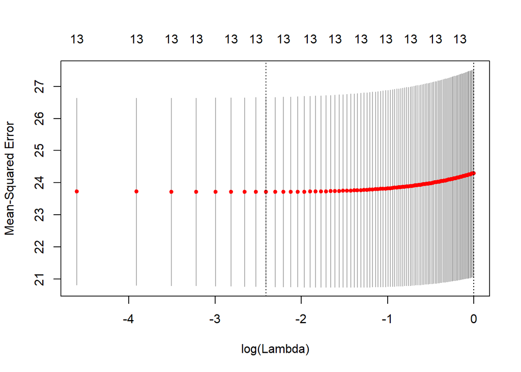

Then we can fit a ridge regression model using this optimal $\lambda$.

```r
ridge.mod=glmnet(x,y,alpha = 0,lambda = cv.ridge$lambda.min)
coef(ridge.mod)
```

```
## 14 x 1 sparse Matrix of class "dgCMatrix"
##                        s0
## (Intercept)  3.474604e+01
## crim        -1.036512e-01
## zn           4.351861e-02
## indus        4.087921e-03
## chas         2.748227e+00
## nox         -1.667372e+01
## rm           3.863468e+00
## age         -3.133597e-04
## dis         -1.417945e+00
## rad          2.688569e-01
## tax         -1.054015e-02
## ptratio     -9.342984e-01
## black        9.275063e-03
## lstat       -5.158902e-01
```

We can see the deviation rario, which is also known as the $R^2$, equals to 0.7404. This means that the fraction of deviance explained is 74.04%, which is pretty good.

```r
ridge.mod$dev.ratio
```

```
## [1] 0.7403828
```

Also, we can compare the LOOCV of it with that of OLS estimation.

```r
min(cv.ridge$cvm)
```

```
## [1] 23.71128
```

This value is a little bit smaller than the OLS estimation, which is 23.72575. Therefore, in this sense, ridge estimation is better at prediction than the OLS estimation.

### (d)

First we use LOOCV to choose the optimal value for the $\lambda$. This time I allowed it to choose it automatically.

```r
cv.lasso = cv.glmnet(x,y,nfolds=k,alpha=1)
cv.lasso$lambda.min
```

```
## [1] 0.019303
```

The plot looks like this:

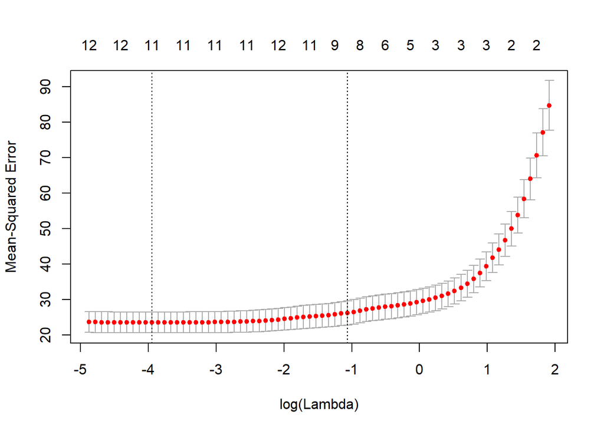

And the lasso estimation using this optimal $\lambda$ is:

```r
lasso.mod <- glmnet(x,y,alpha=1, lambda=cv.lasso$lambda.min)
coef(lasso.mod)
```

```
## 14 x 1 sparse Matrix of class "dgCMatrix"
##                       s0
## (Intercept)  35.03100516
## crim         -0.10150560
## zn            0.04292387
## indus         .
## chas          2.69470749
## nox         -16.63650807
## rm            3.84536681
## age           .
## dis          -1.42738037
## rad           0.26746443
## tax          -0.01044899
## ptratio      -0.93473520
## black         0.00910638
## lstat        -0.52260621
```

From the ourcome we can see that some parameters like indus and age are not selected by the lasso regression method. If we look at the ourcome in part (b) again, these two parameters are just the unsignificant ones in the t-test. So intuitively this is a good estimation.

Also we can see the deviation rario, which is the $R^2$, equals to 0.7404. This means that the fraction of deviance explained is 74.04%, which is pretty good.

```r
lasso.mod$dev.ratio
```

```
## [1] 0.7403799
```

In addition, look at the LOOCV value of lasso estimation:

```r
min(cv.lasso$cvm)
```

```
## [1] 23.60204
```

This value is even smaller than the LOOCV of ridge estimation. Therefore, lasso estimation is better than the ridge and OLS estimation when we are concerned about prediction.

### (e)

To see if any of these three estimations is best at prediction, we can compare the LOOCV of them. First, the LOOCV for OLS estimation is calculated in part (b) with value 23.72575. For ridge estimation:

```r
min(cv.ridge$cvm)
```

```
## [1] 23.71128
```

This value is a little bit smaller than that of OLS estimation. Therefore, ridge estimation is better at prediction than the OLS estimation. Again, look at the LOOCV value of lasso estimation:

```r
min(cv.lasso$cvm)
```

```
## [1] 23.60204
```

This value is even smaller than the LOOCV of ridge estimation. Therefore, in the sense of prediction, lasso estimation is better than the ridge and OLS estimation.

### (f)

```r
B=2000
result1=NULL
set.seed(1)
for (i in 1:B){
  index.boot=sample((1:k),size = k,replace = TRUE)
  data.boot=Boston[index.boot,]
  x.boot=model.matrix(data.boot$medv~.,data=data.boot)[,-1]
  y.boot=data.boot$medv
  mod.boot=glmnet(x.boot,y.boot,alpha=0,lambda=cv.ridge$lambda.min)
  result1=rbind(result1,coef(mod.boot)[9])#9th coefficent is the coefficient for average age of houses
}
apply(result1,2,sd)
```

```
## [1] 0.2065088
```

## Question 2

### (a)

First we generate the sample of data:

```r
n=50
p=40
J=seq(1:p)
Betas=c(rep(1:10),rep(0,30))
set.seed(1)
Xs = matrix(rnorm((n*p),0,1),n,p) #matrix of n by p
errors = rnorm(n,0,1) #vector of n by 1
Y =  Xs %*% Betas + errors
data.sample = data.frame(cbind(Y,Xs))
#Names of variables
Xnames = NULL
for (i in 1:p) {
  Xnames = c(Xnames, paste('X',i,sep=''))
}
datanames = c('Y',Xnames)
names(data.sample) = datanames
head(data.sample)#Sample of data follows the model (1) in question
```

```
##            Y         X1         X2          X3          X4         X5
## 1  39.421298 -0.6264538  0.3981059 -0.62036668  0.45018710  0.4094018
## 2  17.080513  0.1836433 -0.6120264  0.04211587 -0.01855983  1.6888733
## 3   8.859601 -0.8356286  0.3411197 -0.91092165 -0.31806837  1.5865884
## 4 -29.829801  1.5952808 -1.1293631  0.15802877 -0.92936215 -0.3309078
## 5  -6.109547  0.3295078  1.4330237 -0.65458464 -1.48746031 -2.2852355
## 6  36.741283 -0.8204684  1.9803999  1.76728727 -1.07519230  2.4976616
##            X6         X7         X8         X9         X10         X11
## 1  0.13622189  0.8936737  1.4738812  1.0744410  0.96169663  0.07730312
## 2  0.40716760 -1.0472981  0.6772685  1.8956548 -0.60442573 -0.29686864
## 3 -0.06965481  1.9713374  0.3799627 -0.6029973 -0.75287728 -1.18324224
## 4 -0.24766434 -0.3836321 -0.1927984 -0.3908678 -1.55561159  0.01129269
## 5  0.69555081  1.6541453  1.5778918 -0.4162220 -1.45389374  0.99160104
## 6  1.14622836  1.5122127  0.5962341 -0.3756574  0.05633184  1.59396745
##          X12        X13         X14         X15        X16         X17
```

[output cut: 34 more lines]

Next we do the lasso regression on the sample data:

```r
#Lasso regression
x2 = model.matrix(Y~.,data=data.sample)[,-1]
y2 = data.sample$Y
cv.lasso2=cv.glmnet(x2,y2,alpha=1)
cv.lasso2$lambda.min
```

```
## [1] 0.1076861
```

```r
lasso.mod2 = glmnet(x2,y2,alpha=1,lambda=cv.lasso2$lambda.min)
coef(lasso.mod2)
```

```
## 41 x 1 sparse Matrix of class "dgCMatrix"
##                      s0
## (Intercept) -0.02069680
## X1           0.28742993
## X2           1.74575765
## X3           2.83790364
## X4           3.59714183
## X5           5.04399683
## X6           5.66097345
## X7           7.29479082
## X8           7.48800151
## X9           8.79716793
## X10         10.07716780
## X11          .
## X12          .
## X13          .
## X14         -0.04168970
## X15         -0.13465098
## X16          .
## X17          .
## X18          .
## X19          0.22775365
## X20         -0.31765581
## X21          0.03081885
## X22          .
## X23          .
## X24         -0.09056405
## X25         -0.01177765
## X26         -0.05877414
## X27         -0.03240198
## X28          .
## X29          .
## X30          .
## X31          0.02138798
## X32          .
## X33          .
## X34          .
## X35          0.01817427
## X36          .
## X37          .
## X38          0.21106327
## X39          .
## X40         -0.11370523
```

### (b)

To get the OLS estimation, we use the lm fucntion in R. The principle behind this OLS estimation is that to minimise $||\bf{Y}-\bf{X\beta}||_2^2$. Then the OLS estimator can be derived as $(\bf{X}^T\bf{X})^{-1}(\bf{X}^T\bf{Y})$.

```r
ols.mod2=lm(Y~.,data=data.sample)
ols.mod2$coefficients
```

```
## (Intercept)          X1          X2          X3          X4          X5
## -0.18271956  1.23619683  2.07160104  2.54673863  4.38210392  5.42235563
##          X6          X7          X8          X9         X10         X11
##  5.87609009  7.03817082  7.49158069  8.83773558 10.31092417  0.26514748
##         X12         X13         X14         X15         X16         X17
##  0.33622806 -0.03159095 -0.42915154 -0.53796566 -0.34279208  0.01421596
##         X18         X19         X20         X21         X22         X23
## -0.50591313  0.44309614 -0.32166205  0.24267194  0.07555819  0.17261512
##         X24         X25         X26         X27         X28         X29
## -0.09843365 -0.32603742 -0.19200269 -0.28790943 -0.04768041  0.08642519
##         X30         X31         X32         X33         X34         X35
##  0.21389992  0.33913697 -0.01397174 -0.51253684 -0.14009238 -0.12539443
##         X36         X37         X38         X39         X40
##  0.23180773 -0.14452322  0.19334300  0.12141749 -0.19280480
```

### (c)

First we can see how these parameter estimates from OLS and lasso bias from the real parameter value.

```r
bias_lasso=coef(lasso.mod2)-c(0,Betas)
bias_lasso
```

```
## 41 x 1 Matrix of class "dgeMatrix"
##                      s0
## (Intercept) -0.02069680
## X1          -0.71257007
## X2          -0.25424235
## X3          -0.16209636
## X4          -0.40285817
## X5           0.04399683
## X6          -0.33902655
## X7           0.29479082
## X8          -0.51199849
## X9          -0.20283207
## X10          0.07716780
## X11          0.00000000
## X12          0.00000000
## X13          0.00000000
## X14         -0.04168970
## X15         -0.13465098
## X16          0.00000000
## X17          0.00000000
## X18          0.00000000
## X19          0.22775365
## X20         -0.31765581
## X21          0.03081885
## X22          0.00000000
## X23          0.00000000
## X24         -0.09056405
## X25         -0.01177765
## X26         -0.05877414
## X27         -0.03240198
## X28          0.00000000
## X29          0.00000000
## X30          0.00000000
## X31          0.02138798
## X32          0.00000000
## X33          0.00000000
## X34          0.00000000
## X35          0.01817427
## X36          0.00000000
## X37          0.00000000
## X38          0.21106327
## X39          0.00000000
## X40         -0.11370523
```

```r
bias_ols=coef(ols.mod2)-c(0,Betas)
bias_ols
```

```
## (Intercept)          X1          X2          X3          X4          X5
## -0.18271956  0.23619683  0.07160104 -0.45326137  0.38210392  0.42235563
##          X6          X7          X8          X9         X10         X11
## -0.12390991  0.03817082 -0.50841931 -0.16226442  0.31092417  0.26514748
##         X12         X13         X14         X15         X16         X17
##  0.33622806 -0.03159095 -0.42915154 -0.53796566 -0.34279208  0.01421596
##         X18         X19         X20         X21         X22         X23
## -0.50591313  0.44309614 -0.32166205  0.24267194  0.07555819  0.17261512
##         X24         X25         X26         X27         X28         X29
## -0.09843365 -0.32603742 -0.19200269 -0.28790943 -0.04768041  0.08642519
##         X30         X31         X32         X33         X34         X35
##  0.21389992  0.33913697 -0.01397174 -0.51253684 -0.14009238 -0.12539443
##         X36         X37         X38         X39         X40
##  0.23180773 -0.14452322  0.19334300  0.12141749 -0.19280480
```

```r
abs(bias_lasso)/abs(bias_ols)
```

```
## 41 x 1 Matrix of class "dgeMatrix"
##                     s0
## (Intercept) 0.11327086
## X1          3.01684863
## X2          3.55081903
## X3          0.35762227
## X4          1.05431571
## X5          0.10417011
## X6          2.73607288
## X7          7.72293553
## X8          1.00703982
## X9          1.25000955
## X10         0.24818848
## X11         0.00000000
## X12         0.00000000
## X13         0.00000000
## X14         0.09714446
## X15         0.25029661
## X16         0.00000000
## X17         0.00000000
## X18         0.00000000
## X19         0.51400505
## X20         0.98754519
## X21         0.12699801
## X22         0.00000000
## X23         0.00000000
## X24         0.92005171
## X25         0.03612362
## X26         0.30611100
## X27         0.11254226
## X28         0.00000000
## X29         0.00000000
## X30         0.00000000
## X31         0.06306591
## X32         0.00000000
## X33         0.00000000
## X34         0.00000000
## X35         0.14493680
## X36         0.00000000
## X37         0.00000000
## X38         1.09165197
## X39         0.00000000
## X40         0.58974272
```

## Question 3

### (a)

```r
a=c(0.1,0.4,0.8,1.2,1.6,2)
lasso.coef=NULL
set.seed(1)
for (i in 1:length(a)){
  x1=rnorm(100,0,1)
  x2=a[i]*x1
  e=rnorm(100,0,1)
  y3=x1+x2+e
  mod.temp=glmnet(cbind(x1,x2),y3,alpha = 1,lambda = 1)
  mod.coef=as.vector(coef(mod.temp))
  lasso.coef=rbind(lasso.coef,mod.coef)
}
lasso.coef
```

```
##                 [,1]      [,2] [,3]
## mod.coef  0.08196803 0.0000000    0
## mod.coef  0.07728496 0.5344778    0
## mod.coef -0.08108014 0.8657596    0
## mod.coef -0.16527669 1.3705989    0
## mod.coef  0.01142333 1.8698093    0
## mod.coef -0.16082677 2.1375093    0
```

In this outcome, each row represents a seperate $a$ value, and three columns represent the parameter estimations for intercept, $x_1$, and $x_2$ seperately.

### (b)

We can see from the outcome in part (a) that, except from $a=0.1$, no matter what value $a$ takes, lasso always select variable $x_1$.

For lasso estimation, the objective function we want to minimise is
$$||\bf{Y}-\bf{X\beta}||_2^2+\lambda||\bf{\beta}||_1$$
The options to select from are on the line $\beta_1+a\beta_2-1-1=0$. If we assume that a variable selection is going to be made, then there are only two options left: $\beta_1=1+a,\ \beta_2=0$ and $\beta_1=0,\ \beta_2=\frac{1}{a}+1$. This comes from the fact that $x_2=ax_1$.

When $a<1$, obviously $\beta_1=1+a,\ \beta_2=0$ gives a smaller $||\bf{\beta}||_1$. In the meanwhile, $\beta_1=1+a,\ \beta_2=0$ and $\beta_1=0,\ \beta_2=\frac{1}{a}+1$ should give the same value of $||\bf{Y}-\bf{X\beta}||_2^2$. Therefore, to minimise the objective function, variable $x_1$ is selected.

When $a>1$, it is a little tricky cause if we consider the same idea above, $x_2$ seems like shold be selected. However, still $x_1$ is selected. My guess is that lasso not only does variable selection, it does shrinkage as well. When considering the shrinkage, we are not actually select from the line $\beta_1+a\beta_2-1-1=0$. We can also see the shrinkage effect from the regression outcome in part (a). For example, when $a=0.4$, if only $x_1$ is selected, the unbiased parameter should be $1.4$. However, the estimated parameter is just $0.534$. Therefore, this shrinkage effect might influence our final variable selection and result in selecting $x_1$ even when $a>1$.